# Central Limit Theorem

*Hello! Let’s call the libraries we need.*

```r
# Load necessary libraries
library(ggplot2)
library(gridExtra)
library(dplyr)
```

*We’re going to explore how the Central Limit Theorem works using simulations. We’ll start by defining our population distribution. Currently, it’s set to a Poisson distribution with a customizable lambda parameter. However, this could be set to any distribution, for example: exponential, gamma, uniform, normal, or chi-squared distributions.*

*Next, we’ll specify the number of data points to sample from our population distribution using the `sample_size` variable. As this number increases, the standard deviation of the normal distribution, generated by the Central Limit Theorem, decreases.*

*This makes sense. As we collect more samples, our sample means become more accurate in estimating the population mean. For instance, if we took two data points from the population, their mean is likely to differ from the population mean. This is just due to random variation. In contrast, if we select 50 data points, the sample mean of these values is likely to be much closer to the population mean.*

*Additionally, the `num_samples` variable lets us decide how many sample means to calculate and plot. As this number increases, the distribution of sample means becomes more normally distributed, in accordance with the Central Limit Theorem.*

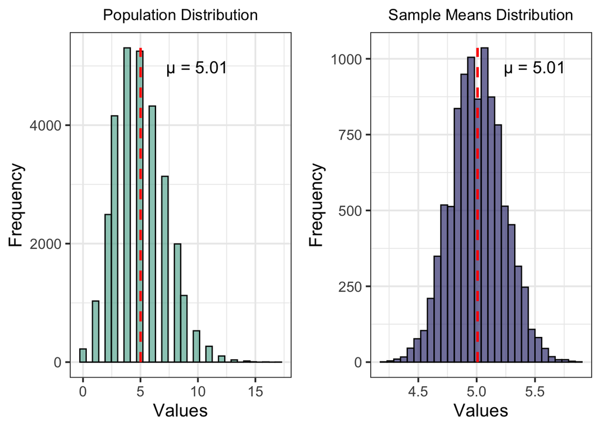

```r
# Define parameters
lambda <- 5    # Rate parameter of our Poisson distribution
sample_size <- 100   # Number of data points for each sample
num_samples <- 10000 # Number of means to collect

# Generate original dataset
original_dataset <- rpois(30000, lambda = lambda)

# Theoretical mean and standard deviation for the population distribution
theoretical_mean <- mean(original_dataset)
theoretical_sd <- sd(original_dataset) / sqrt(sample_size)

# Convert original dataset to a data frame
original_dataframe <- data.frame(original_values = original_dataset)

# Function to generate means dataset using vectorized operations
generate_means_dataset <- function(original_data, sample_size, num_samples) {
  replicate(num_samples, mean(sample(original_data, sample_size, replace = TRUE)))
}

# Generate means dataset
means_dataset <- generate_means_dataset(original_dataset, sample_size, num_samples)
means_dataframe <- data.frame(means_values = means_dataset)

# Calculate means for both distributions
mean_original <- mean(original_dataset)
mean_means <- mean(means_dataframe$means_values)
sd_means <- sd(means_dataframe$means_values)


# Function to calculate number of bins using Sturges' rule
sturges_rule <- function(n) {
  ceiling(log2(n) + 1)
}

# Calculate maximum y-values for annotations
calculate_max_y <- function(dataframe, column) {
  max(ggplot_build(
    ggplot(dataframe, aes(x = !!sym(column))) +
      geom_histogram(bins = 2 * sturges_rule(nrow(dataframe)))
  )$data[[1]]$count)
}

max_y_original <- calculate_max_y(original_dataframe, "original_values")
max_y_means <- calculate_max_y(means_dataframe, "means_values")

# Create histograms using ggplot with enhanced visual appeal
create_histogram_plot <- function(dataframe, column, mean_value, max_y, title, fill_color) {
  ggplot(dataframe, aes(x = !!sym(column))) +
    geom_histogram(bins = 2 * sturges_rule(nrow(dataframe)),
                   fill = fill_color, color = "black", alpha = 0.7) +
    annotate("segment", x = mean_value, xend = mean_value, y = 0, yend = max_y,
             color = "red", linetype = "dashed", linewidth = 1) +
    annotate("text", x = mean_value + 3/4*sd(dataframe[[column]]), y = max_y * 0.9,
             label = paste("μ =", round(mean_value, 2)),
             color = "black", vjust = -0.5, hjust = -0.1, size = 5) +
    labs(title = title, x = "Values", y = "Frequency") +
    theme_bw(base_size = 15) +
    theme(plot.title = element_text(hjust = 0.5, size = 13))
}

original_plot <- create_histogram_plot(original_dataframe, "original_values", mean_original, max_y_original, "Population Distribution", "#69b3a2")
means_plot <- create_histogram_plot(means_dataframe, "means_values", mean_means, max_y_means, "Sample Means Distribution", "#404080")

# Arrange the plots side by side
grid.arrange(original_plot, means_plot, ncol = 2)
```

*Notice how close the population mean and the mean of the normal distribution are, perhaps with rounding they appear to be equal. We can see that given enough samples, the distribution of sample means always tends towards normality no matter what our initial distribution looks like.*

*We can visualize what our simulated distribution looks like as compared to what the Central Limit Theorem suggests.*

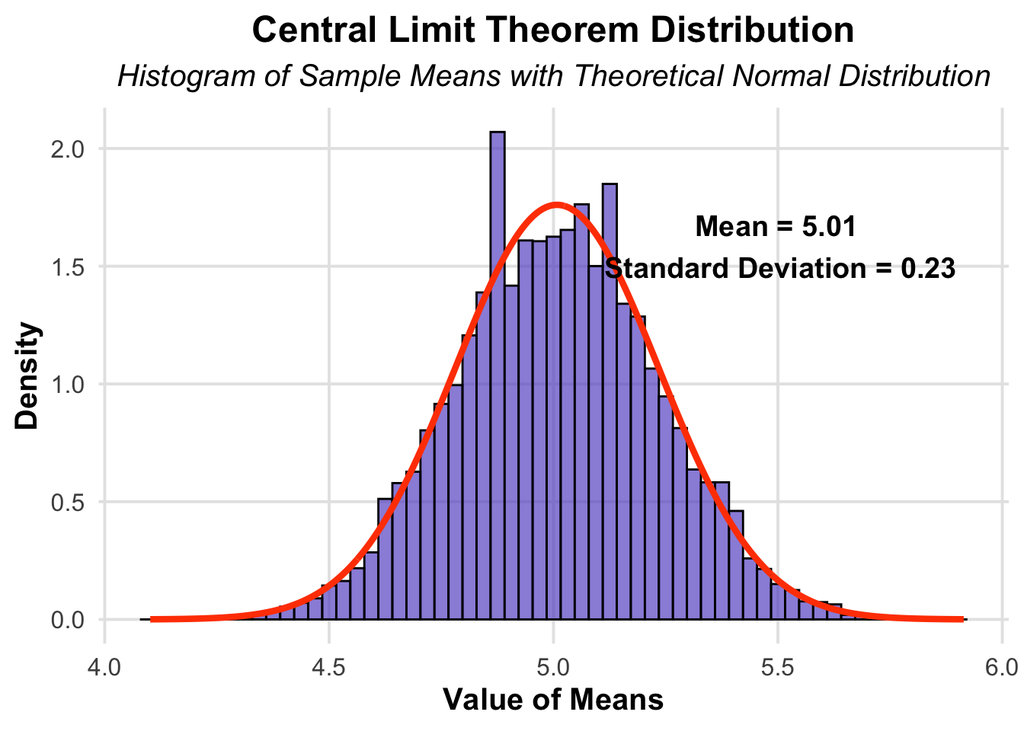

```r
# Find the theoretical normal distribution
means_values <- seq(mean_means - 4 * sd_means,
                    mean_means + 4 * sd_means,
                    length.out = 500)
means_perfect_normal <- dnorm(means_values, mean = mean_means, sd = sd_means)
means_perfect_normal_df <- data.frame(Values = means_values, Density = means_perfect_normal)

# Calculate bins using the Freedman-Diaconis rule
freedman_diaconis_bins <- function(data) {
  bin_width <- 2 * IQR(data) / (length(data)^(1/3))
  bins <- (max(data) - min(data)) / bin_width
  return(ceiling(bins))
}

fd_bins <- freedman_diaconis_bins(means_dataframe$means_values)

# Create the plot for Central Limit Theorem
clt_plot <- ggplot(means_dataframe, aes(x = means_values)) +
  geom_histogram(aes(y = after_stat(density)), bins = fd_bins,
                 fill = "#6A5ACD", color = "black", alpha = 0.7) +
  geom_line(data = means_perfect_normal_df, aes(x = Values, y = Density),
            color = "#FF4500", linewidth = 1.5) +
  annotate("text", x = mean_means + 2.2 * sd_means, y = max(means_perfect_normal_df$Density) * 0.6,
           label = paste("Mean =", round(mean_means, 2), "\nStandard Deviation =", round(sd_means, 2)),
           color = "black", size = 5, angle = 0, vjust = -1.5, hjust = 0.5, fontface = "bold") +
  labs(title = "Central Limit Theorem Distribution",
       subtitle = "Histogram of Sample Means with Theoretical Normal Distribution",
       x = "Value of Means", y = "Density") +
  theme_minimal(base_size = 15) +
  theme(plot.title = element_text(hjust = 0.5, face = "bold"),
        plot.subtitle = element_text(hjust = 0.5, face = "italic"),
        axis.title.x = element_text(face = "bold"),
        axis.title.y = element_text(face = "bold"),
        panel.grid.major = element_line(color = "grey90"),
        panel.grid.minor = element_blank())

# Print the CLT plot
print(clt_plot)
```

*We can see that as the number of samples we take increases, the more our distribution tends toward a normal distribution.*

*The Central Limit Theorem claims that for any given population, the distribution of the sample means will approach ~* $N\left(\mu, \frac{\sigma}{\sqrt{n}}\right)$.

*We can calculate how closely the distribution of sample means that we have from our simulation holds to the Central Limit Theorem with the following table.*

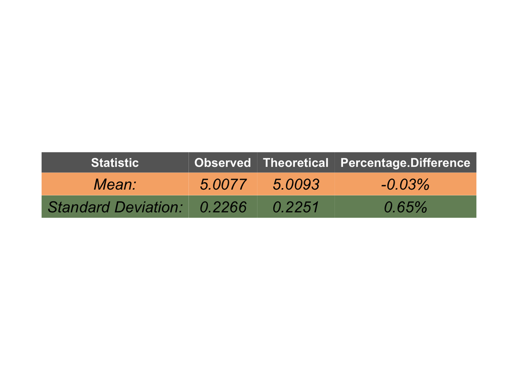

```r
# Calculate percentage differences
percentage_diff_mean <- ((mean_means - theoretical_mean) / theoretical_mean) * 100
percentage_diff_sd <- ((sd_means - theoretical_sd) / theoretical_sd) * 100

# Create a table with observed and theoretical values and percentage differences
table_data <- data.frame(
  Statistic = c("Mean:", "Standard Deviation:"),
  Observed = c(round(mean_means, 4), round(sd_means, 4)),
  Theoretical = c(round(theoretical_mean, 4), round(theoretical_sd, 4)),
  `Percentage Difference` = c(paste0(round(percentage_diff_mean, 2), "%"), paste0(round(percentage_diff_sd, 2), "%"))
)

# Customize the table theme for a vibrant look
custom_theme <- ttheme_default(
  core = list(
    bg_params = list(fill = c("#F7B076", "#748F67"), col = NA),
    fg_params = list(fontface = 3, fontsize = 15, hjust = 0.5)
  ),
  colhead = list(
    fg_params = list(col = "white", fontface = 2),
    bg_params = list(fill = "grey40", col = NA)
  )
)

# Create the table using tableGrob
table_grob <- tableGrob(table_data, rows = NULL, theme = custom_theme)

# Convert the tableGrob to a ggplot object
ggplot_table <- ggplot() +
  annotation_custom(table_grob) +
  theme_void()

# Print the ggplot table
print(ggplot_table)
```

*We can see only a slight difference between the mean and standard deviation suggested by the Central Limit Theorem, and what our simulation actually yielded.*

*Finally, lets take a look at a different population distribution to get a feel for how the central limit theorem “tightens up” the range of a distribution.*

*We can set our own sample size and number of samples as done previously and view what happens to the standard deviation of our sample means. As the sample size goes up, the standard deviation of the distribution of sample means falls.*

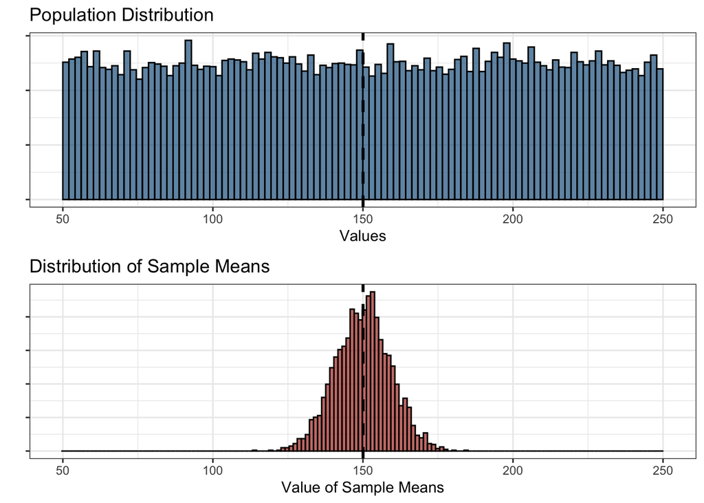

```r
#Again we have our two variables.
sample_size <- 40 #Sets the number of data points we pull from the population for each sample. This is the "n" in our normal distribution formula.
num_samples <- 3000 #Sets the number of samples we calculate the mean of.

# Additional demonstration with a uniform distribution
set.seed(124)

line_original_dataset <- runif(30000, min = 50, max = 250)
line_original_dataframe <- data.frame(line_original_dataset)

line_means_dataset <- generate_means_dataset(line_original_dataset, sample_size, num_samples)
line_means_dataframe <- data.frame(line_means_dataset)

line_original_df_plot <- ggplot(line_original_dataframe, aes(x = line_original_dataset, y = after_stat(density))) +
  geom_histogram(bins = 100, fill = "#1F618D", color = "black", alpha = 0.7) +
  geom_vline(aes(xintercept = mean(line_original_dataset)), linetype = "dashed", color = "black", linewidth = 1) +
  labs(title = "Population Distribution", x = "Values", y = "") +
  scale_x_continuous(limits = c(49, 251)) +
  theme_bw() +
  theme(axis.text.y = element_blank())

line_means_df_plot <- ggplot(line_means_dataframe, aes(x = line_means_dataset, y = after_stat(density))) +
  geom_histogram(bins = 150, fill = "#B03A2E", color = "black", alpha = 0.7) +
  geom_vline(aes(xintercept = mean(line_means_dataset)), linetype = "dashed", color = "black", linewidth = 1) +
  scale_x_continuous(limits = c(49, 251)) +
  labs(title = "Distribution of Sample Means", x = "Value of Sample Means", y = "") +
  theme_bw() +
  theme(axis.text.y = element_blank())

grid.arrange(line_original_df_plot, line_means_df_plot, nrow = 2)
```

*The central limit theorem is crucial to inferential statistics in its reliability. It is the backbone of confidence intervals and hypothesis testing. It’s good to get a sense for how simulations fall in line with what it states.*

*Frequently we’ll just be citing it as a theorem that we need in order to conduct tests and make claims about population parameters. But it’s important to see how it works in application, not just as some all-important theorem.*